# model09_iv-temp_dv-scl

Heejung Jung

2022-12-07

We model this as a function of “cue” and “stimulus intensity”, while allowing for random effects from participants.

# Why use multilevel models?

- content copied from http://www.bristol.ac.uk/cmm/learning/multilevel-models/what-why.html

> There are a number of reasons for using multilevel models:
> 1. Correct inferences: Traditional multiple regression techniques treat the units of analysis as independent observations. One consequence of failing to recognise hierarchical structures is that standard errors of regression coefficients will be underestimated, leading to an overstatement of statistical significance. Standard errors for the coefficients of higher-level predictor variables will be the most affected by ignoring grouping.
> 2. Substantive interest in group effects: In many situations a key research question concerns the extent of grouping in individual outcomes, and the identification of ‘outlying’ groups. In evaluations of school performance, for example, interest centres on obtaining ‘value-added’ school effects on pupil attainment. Such effects correspond to school-level residuals in a multilevel model which adjusts for prior attainment.
> 3. Estimating group effects simultaneously with the effects of group-level predictors: An alternative way to allow for group effects is to include dummy variables for groups in a traditional (ordinary least squares) regression model. Such a model is called an analysis of variance or fixed effects model. In many cases there will be predictors defined at the group level, eg type of school (mixed vs. single sex). In a fixed effects model, the effects of group-level predictors are confounded with the effects of the group dummies, ie it is not possible to separate out effects due to observed and unobserved group characteristics. In a multilevel (random effects) model, the effects of both types of variable can be estimated.
> 4. Inference to a population of groups: In a multilevel model the groups in the sample are treated as a random sample from a population of groups. Using a fixed effects model, inferences cannot be made beyond the groups in the sample.

load libraries

# Terminology

**factor**

In experimental designs, factor is the equivalent of independent variable. In R, one can factorize a categorical variable by using the `factor` function. Thereby we interchangeably use the term factor in lieu of independent variable.

From this, the term `factorial design` originates.

**level**

within each independent variable, a researcher may determine different levels. Since the purpose of linear models is to compare at least one condition to another, a factor contains more than one level.

**group variable**

Unit of analysis. In most fMRI experiments that collect individual data, the group variable would be the individual participant. However, in other research questions, the group variable could easily be more than one individual. For instance, a dyad of participants that carry out conversations, multiple patients that see an identical doctor, a classroom full of individuals, or voting districts could serve as a grouping variable, depending on the research question.

- ```
  factor:
  group
  ```

# Model versions

## Summary of models

### Method 1: repeated measures and `one-sample t-tests`

- Data Matrix: Wide form
  - row (83 subject)
  - column (6 conditions: highCue x highStim, highCue x medStim, highCue x lowStim, lowCue x highStim,lowCue x medStim, lowCue x lowStim)
- Model: Use “lm”. One-sample t-test
- Effect size (cohen’s d): mean / sd (intersubject slope) > use degrees of freedom.

load data and combine participant data

```r
main_dir = dirname(dirname(getwd()))
analysis_dir <- file.path(main_dir, "analysis", "physio", "physio01_SCL", as.character(Sys.Date()))
dir.create(analysis_dir, showWarnings = FALSE, recursive = TRUE)
```

```r
analysis_dir
```

```
## [1] "/Users/h/Dropbox/projects_dropbox/social_influence_analysis/analysis/physio/physio01_SCL/2022-12-08"
```

```r
# parameters _____________________________________ # nolint
tonic = read.csv("/Users/h/Dropbox/projects_dropbox/social_influence_analysis/analysis/physio/physio01_SCL/sub-all_ses-all_run-all_runtype-pain_epochstart--1_epochend-15_samplingrate-25_ttlindex-2_physio-scltimecourse.csv")
```

This is the data that we will use

```
##   src_subject_id session_id param_task_name param_run_num param_cue_type
## 1             15          1            pain             1       high_cue
## 2             15          1            pain             1       high_cue
## 3             15          1            pain             1        low_cue
## 4             15          1            pain             1       high_cue
## 5             15          1            pain             1       high_cue
## 6             15          1            pain             1        low_cue
##   param_stimulus_type param_cond_type event02_expect_RT event02_expect_angle
## 1            med_stim               5          2.088140             44.51030
## 2            low_stim               4          1.417380            122.03075
## 3            med_stim               2          1.967787             23.16839
## 4           high_stim               6          1.453132            114.91966
## 5           high_stim               6          2.223133            111.20282
## 6           high_stim               3          1.600805             92.07003
##   event04_actual_RT event04_actual_angle trial_num trial_order   iv_stim
```

[output cut: 461 more lines]

## Method 3 multilevel modeling

### Method 3 multilevel modeling

contrast-coding for multi-level modeling (code-hidden)

```r
#contrast code 1 linear
tonic$stim_con_linear[tonic$param_stimulus_type == "low_stim"] <- -0.5
tonic$stim_con_linear[tonic$param_stimulus_type == "med_stim"] <- 0
tonic$stim_con_linear[tonic$param_stimulus_type == "high_stim"] <- 0.5

# contrast code 2 quadratic
tonic$stim_con_quad[tonic$param_stimulus_type == "low_stim"] <- -0.33
tonic$stim_con_quad[tonic$param_stimulus_type == "med_stim"] <- 0.66
tonic$stim_con_quad[tonic$param_stimulus_type == "high_stim"] <- -0.33

# social cue contrast
tonic$social_cue[tonic$param_cue_type == 'low_cue'] <- -0.5 # social influence task
tonic$social_cue[tonic$param_cue_type == 'high_cue'] <- 0.5 # no influence task
tonic$cue_factor = factor(tonic$social_cue)
```

```r
# parameters ___________________________________________________________________
tonic$subject = factor(tonic$src_subject_id)
subject_varkey <- "subject"
iv <- "cue_factor"
stim_con1 = "stim_con_linear"
stim_con2 = "stim_con_quad"
dv <- "mean_signal" # DON"T USE EDA_Peak_Amplitude (misleading)
iv_keyword <- "cue-stim"
dv_keyword <- "scl_peak"
xlab <- ""
taskname <- "full"
#ylim = c(-1,1)
#tonic_task =
```

multi-level modeling using **lmer**

```r
fullmodel = lmer(mean_signal ~ 1+ cue_factor + stim_con_linear + stim_con_quad + cue_factor:stim_con_linear + cue_factor:stim_con_quad + (1  |subject), data = tonic)

# output of model
summary(fullmodel)
```

```
## Linear mixed model fit by REML. t-tests use Satterthwaite's method [
## lmerModLmerTest]
## Formula: mean_signal ~ 1 + cue_factor + stim_con_linear + stim_con_quad +
##     cue_factor:stim_con_linear + cue_factor:stim_con_quad + (1 |      subject)
##    Data: tonic
##
## REML criterion at convergence: 17836.2
##
## Scaled residuals:
##      Min       1Q   Median       3Q      Max
## -10.6423  -0.2099  -0.0304   0.2478   8.4094
##
## Random effects:
##  Groups   Name        Variance Std.Dev.
##  subject  (Intercept) 0.01047  0.1023
##  Residual             0.64710  0.8044
## Number of obs: 7384, groups:  subject, 72
##
## Fixed effects:
##                                 Estimate Std. Error         df t value Pr(>|t|)
## (Intercept)                    7.638e-02  1.820e-02  1.270e+02   4.197 5.05e-05
## cue_factor0.5                  7.951e-02  1.872e-02  7.310e+03   4.247 2.19e-05
## stim_con_linear                1.302e-01  3.241e-02  7.310e+03   4.018 5.92e-05
## stim_con_quad                 -2.828e-03  2.835e-02  7.310e+03  -0.100    0.921
## cue_factor0.5:stim_con_linear -4.488e-02  4.585e-02  7.310e+03  -0.979    0.328
## cue_factor0.5:stim_con_quad    2.701e-02  4.012e-02  7.310e+03   0.673    0.501
##
## (Intercept)                   ***
## cue_factor0.5                 ***
## stim_con_linear               ***
## stim_con_quad
## cue_factor0.5:stim_con_linear
## cue_factor0.5:stim_con_quad
## ---
## Signif. codes:  0 '***' 0.001 '**' 0.01 '*' 0.05 '.' 0.1 ' ' 1
##
## Correlation of Fixed Effects:
##                    (Intr) c_f0.5 stm_cn_l stm_cn_q c_fctr0.5:stm_cn_l
## cue_fctr0.5        -0.514
## stim_cn_lnr         0.000  0.000
## stim_con_qd         0.000  0.000  0.000
## c_fctr0.5:stm_cn_l  0.000  0.001 -0.707    0.000
## c_fctr0.5:stm_cn_q  0.000  0.000  0.000   -0.707    0.000
```

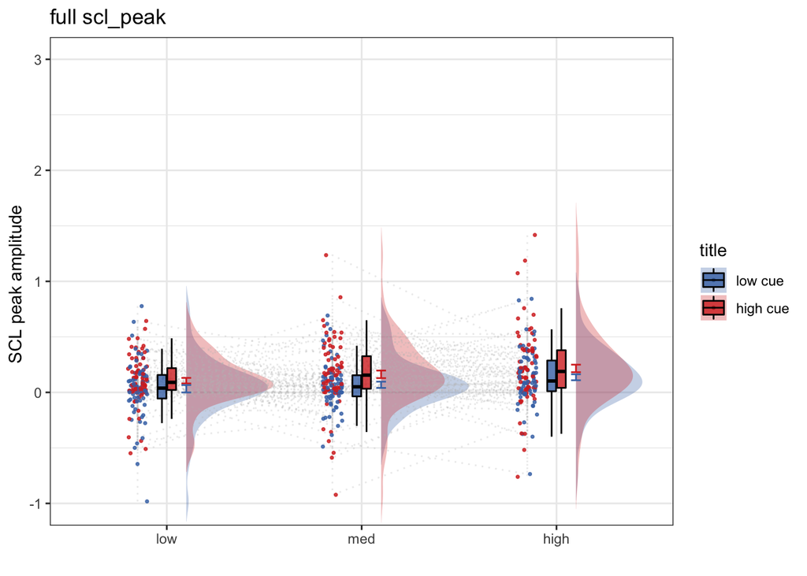

```r
cooksd <- cooks.distance(fullmodel)
influential <- as.numeric(names(cooksd)[
    (cooksd > (4 / as.numeric(length(unique(tonic$subject)))))])
data_screen <- tonic[-influential, ]

# reordering for plots _________________________________________________________
tonic$cue_name[tonic$param_cue_type == "high_cue"] <- "high cue"
tonic$cue_name[tonic$param_cue_type == "low_cue"] <- "low cue" # no influence task

tonic$stim_name[tonic$param_stimulus_type == "high_stim"] <- "high" # no influence task
tonic$stim_name[tonic$param_stimulus_type == "med_stim"] <- "med" # no influence task
tonic$stim_name[tonic$param_stimulus_type == "low_stim"] <- "low" # no influence task

tonic$stim_ordered <- factor(tonic$stim_name, levels=c("low", "med", "high"))
tonic$cue_ordered <- factor(tonic$cue_name, levels=c("low cue", "high cue"))
model_iv1 = "stim_ordered";model_iv2 = "cue_ordered"

# summary statistics for plots _________________________________________________
subjectwise <- meanSummary(tonic, c("subject", model_iv1, model_iv2), dv)
try <- na.omit(subjectwise)
groupwise <- summarySEwithin(
        data = try,
        measurevar = "mean_per_sub", # variable created from above
        withinvars = c(model_iv1, model_iv2), # iv
        idvar = "subject"
    )

subjectwise_mean <- "mean_per_sub";
group_mean <- "mean_per_sub_norm_mean"
se <- "se";
ggtitle <- paste(taskname, dv_keyword);
title <- paste(taskname, " - RT")
xlab <- "";
ylab <- "SCL peak amplitude ";
w = 5; h = 3;
ylim = c(-1,3)
if (any(startsWith(dv_keyword, c("expect", "Expect")))) {
        color <- c("#1B9E77", "#D95F02")
    } else {
        color <- c("#4575B4", "#D73027")
    }
plot_savefname <- file.path(
        analysis_dir,
        paste("raincloud_task-", taskname,
              "_iv-", iv_keyword,"_dv-", dv_keyword,
              "_", as.character(Sys.Date()), ".png",
              sep = ""
        )
    )
plot_rainclouds_twofactor(
        try, groupwise,
        model_iv1, model_iv2, subjectwise_mean, group_mean, se, "subject",
        ggtitle, title, xlab, ylab, task_name, ylim,
        w, h, dv_keyword, color, plot_savefname
    )
```

# Temperature predicting rating

```r
temp_pain = lmer(event02_expect_angle ~ 1+ stim_con_linear + stim_con_quad + (1  |subject), data = tonic)

# output of model
summary(temp_pain)
```

```
## Linear mixed model fit by REML. t-tests use Satterthwaite's method [
## lmerModLmerTest]
## Formula: event02_expect_angle ~ 1 + stim_con_linear + stim_con_quad +
##     (1 | subject)
##    Data: tonic
##
## REML criterion at convergence: 65752.7
##
## Scaled residuals:
##     Min      1Q  Median      3Q     Max
## -4.3344 -0.7160  0.0366  0.6725  3.2959
##
## Random effects:
##  Groups   Name        Variance Std.Dev.
##  subject  (Intercept) 774.3    27.83
##  Residual             770.4    27.76
## Number of obs: 6900, groups:  subject, 71
##
## Fixed effects:
##                  Estimate Std. Error        df t value Pr(>|t|)
## (Intercept)       63.8808     3.3257   70.2200  19.208   <2e-16 ***
## stim_con_linear   -0.2688     0.8180 6827.6600  -0.329   0.7424
## stim_con_quad     -1.3032     0.7173 6828.1475  -1.817   0.0693 .
## ---
## Signif. codes:  0 '***' 0.001 '**' 0.01 '*' 0.05 '.' 0.1 ' ' 1
##
## Correlation of Fixed Effects:
##             (Intr) stm_cn_l
## stim_cn_lnr 0.000
## stim_con_qd 0.001  0.000
```

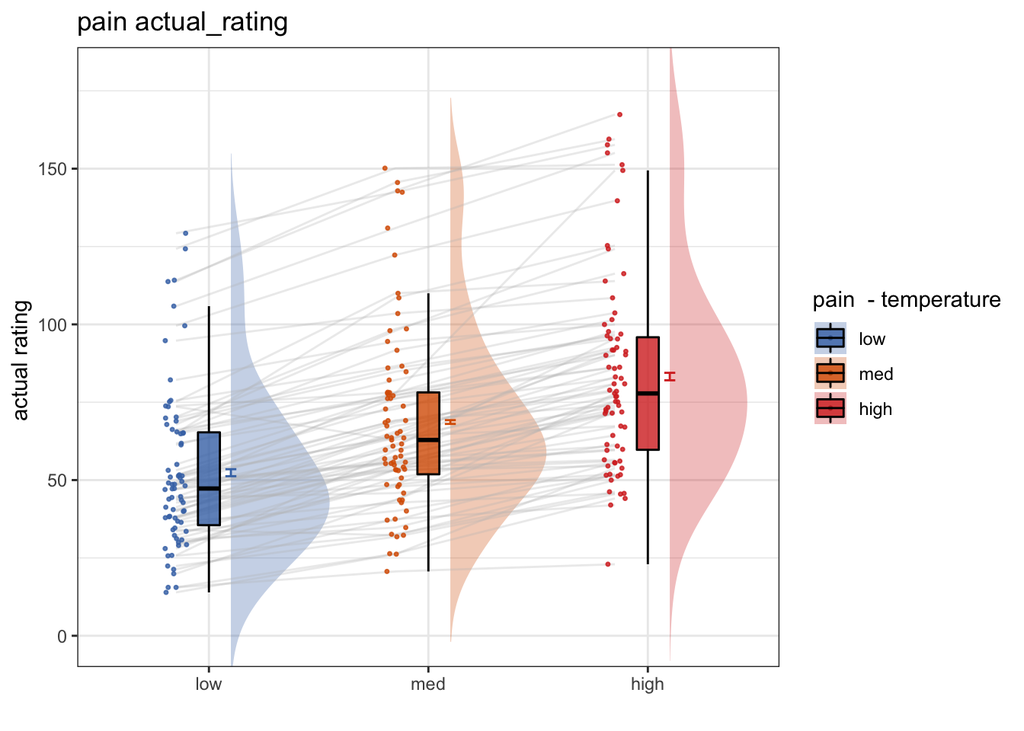

```r
key = 'actual'
if (any(startsWith(key, c("expect", "Expect")))) {
        dv = 'event02_expect_angle'
        dv_keyword = 'expect_rating'
        ylab <- "expect rating ";
    } else {
        dv = 'event04_actual_angle'
        dv_keyword = 'actual_rating'
        ylab <- "actual rating ";
    }
# dv = 'event02_expect_angle'
iv_keyword = 'temp'
# dv_keyword = 'expect_rating'
task_name = 'pain'
subjectwise_mean <- "mean_per_sub";
group_mean <- "mean_per_sub_norm_mean"
se <- "se";
ggtitle <- paste(task_name, dv_keyword);
title <- paste(task_name, " - temperature")
xlab <- "";
# ylab <- "expect rating ";
w = 5; h = 3;
ylim = c(-1,180)


cooksd_temp <- cooks.distance(temp_pain)
influential_temp <- as.numeric(names(cooksd_temp)[
    (cooksd > (4 / as.numeric(length(unique(tonic$subject)))))])
data_screen_temp <- tonic[-influential_temp, ]

# reordering for plots _________________________________________________________

tonic$stim_name[tonic$param_stimulus_type == "high_stim"] <- "high" # no influence task
tonic$stim_name[tonic$param_stimulus_type == "med_stim"] <- "med" # no influence task
tonic$stim_name[tonic$param_stimulus_type == "low_stim"] <- "low" # no influence task

tonic$stim_ordered <- factor(tonic$stim_name, levels=c("low", "med", "high"))
#tonic$cue_ordered <- factor(tonic$cue_name, levels=c("low cue", "high cue"))
model_iv1 = "stim_ordered"; #model_iv2 = "cue_ordered"

# summary statistics for plots _________________________________________________
subjectwise_temp <- meanSummary(tonic, c("subject", model_iv1), dv)
try <- na.omit(subjectwise_temp)
groupwise_temp <- summarySEwithin(
        data = try,
        measurevar = "mean_per_sub", # variable created from above
        withinvars = c(model_iv1), # iv
        idvar = "subject"
    )

if (any(startsWith(dv_keyword, c("expect", "Expect")))) {
        color <- c("#7678ed", "#f7b801", "#f18701")
    } else {
        color <- c("#4575B4",  "#D95F02", "#D73027")
    }
plot_savefname <- file.path(
        analysis_dir,
        paste("raincloud_task-", taskname,
              "_iv-", iv_keyword,"_dv-", dv_keyword,
              "_", as.character(Sys.Date()), ".png",
              sep = ""
        )
    )
plot_rainclouds_onefactor(
        subjectwise = try, groupwise = groupwise_temp,
        iv = model_iv1, subjectwise_mean = subjectwise_mean, group_mean = group_mean,
        se = se, subject = "subject",
        ggtitle = ggtitle, title = title, xlab = xlab, ylab = ylab, taskname = task_name, ylim = ylim,
        w = w, h = h, dv_keyword = dv_keyword, color, plot_savefname
    )
```